# Bullet Trajectory Simulation

Jake Bova

# Introduction

### Equations of Motion

The equations of motion for a projectile with drag can be represented in two dimensions, considering the range $(x)$ and drop $(y)$ of the projectile. These equations are:

$$a_x = -\frac{1}{2b_c} \rho C_d^G(m) v^2 \frac{v_x}{|v|}$$

$$a_y = -g - \frac{1}{2b_c} \rho C_d^G(m) v^2 \frac{v_y}{|v|}$$

where:

| Variable | Description |
| --- | --- |
| $a_x$ and $a_y$ | accelerations in the x and y directions, respectively. |
| $b_c$ | ballistic coefficient. |
| $\rho$ | density of air. |
| $C_d^G(m)$ | drag coefficient of the reference projectile, which is a function of the Mach number $(m)$. |
| $v$ | magnitude of the velocity. |
| $v_x$ and $v_y$ | velocities in the x and y directions, respectively. |
| $g$ | acceleration due to gravity. |

### Drag Force

The drag force acting on the projectile is given by:

$$F_d = -\frac{1}{2} \rho v^2 A C_d \hat{v}$$

where:

| Variable | Description |
| --- | --- |
| $C_d$ | the drag coefficient of the projectile. |
| $A$ | the cross-sectional area of the projectile. |
| $\hat{v}$ | the unit vector in the direction of velocity. |

### Ballistic Coefficient

The ballistic coefficient $(b_c)$ is a measure of a projectile's ability to overcome air resistance. It is defined as:

$$b_c = \frac{S_d}{f}$$

where:

| Variable | Description |
| --- | --- |
| $S_d$ | the sectional density of the projectile, given by $S_d = \frac{m}{A}$, where $m$ is the mass of the projectile. |
| $f$ | the form factor of the projectile, defined as the ratio of the projectile's drag coefficient to the drag coefficient of a reference projectile $(C_d^G)$. |

### Mach Number

The Mach number $(m)$ is a dimensionless quantity representing the speed of the projectile relative to the speed of sound. It is calculated as:

$$m = \frac{|v|}{v_s}$$

where $v_s$ is the speed of sound in air.

### Problem Statement

In this project, we aim to model the trajectory of a bullet using the G1 and G7 ballistic models and compare the results with real-world data. The goal is to determine which model best fits the chosen cartridge and to explore potential improvements to the models.

G1 and G7 are standard models used to represent the drag coefficients of bullets at different velocities. The G1 model is based on a flat-based bullet with a specific shape, while the G7 model is based on a boat-tail bullet with a different shape.

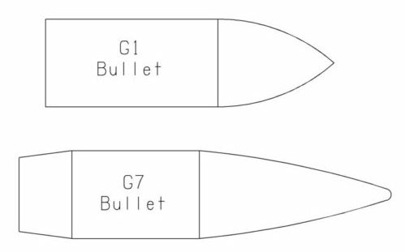

G1 and G7 cartridges follow distinct drag coefficient curves that are used to calculate the drag force acting on the projectile.

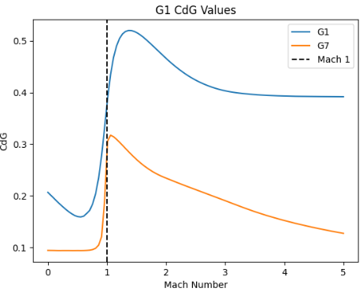

# Methods

### Numerical Methods

In this project, we employ several numerical methods to solve the equations of motion for the projectile. The primary method used is the Euler-Richardson method, which is a second-order method for approximating the solution of ordinary differential equations. Specifically, the method uses the midpoint rule to estimate the derivative at the midpoint of the interval and then uses this estimate to update the solution. The `solve_ode` function implements this method to integrate the equations of motion and calculate the projectile's trajectory over time.

### Algorithms

Algorithms for data interpolation and unit conversion are implemented/used in this project. The `BallisticModel` class includes methods for interpolating the G1 and G7 drag coefficient data and converting between imperial and metric units. The interpolation is performed using the `interp1d` function from the SciPy library, which provides a linear interpolation between data points.

### Program Overview

A system of modules is used in this program, including a module for defining the ballistic models (G1 and G7), a module for solving the equations of motion, and a module for analyzing and visualizing the results. All modules are defined in a Jupyter notenook rather than separate python files. The `BallisticModel` class encapsulates the data for the G1 and G7 models, including the drag coefficient tables, relevant constants, and methods for calculating the drag force and converting between units. The `solve_ode` function handles the numerical integration of the equations of motion, while other functions and scripts are used for data analysis, plotting, and table generation. Integration methods are implemented in various `Euler` classes.

## Determining if the output is correct

### Verification of Results

Verifying the results is an important step in this project. The real world data is used from the cartridge manufacturer website. The comparison is performed by plotting the trajectories and generating tables that show the projectile's position and velocity at various points along the trajectory.

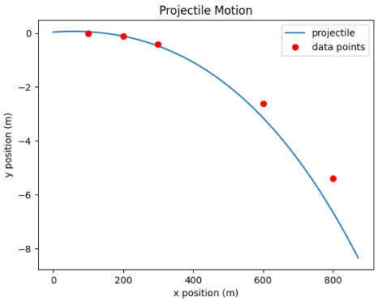

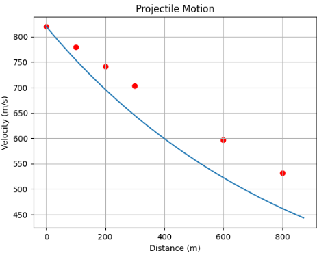

*Figure 1: Trajectory of a bullet using the G1 model compared to real-world data.*

*Figure 2: Projectile velocity vs distance using the G1 model compared to real-world data.*

### Ensuring Reproducibility

Results of this project are easy to reproduce. Parameters can be changed freely before each run. The `BallisticModel` class encapsulates the data and methods for the ballistic models, making it easy to reproduce the experiments with different parameters or cartridges. The ODE solver and data analysis functions are modular and can be reused for different scenarios / simulations.

# Analysis

### Firing Angle calculation

Optimal firing angle is calculated using an iterative approach across a range of angles. The difference in the y direction of the projectile between the numerical solution and the real world data is minimized to find thhe appropriate firing angle.

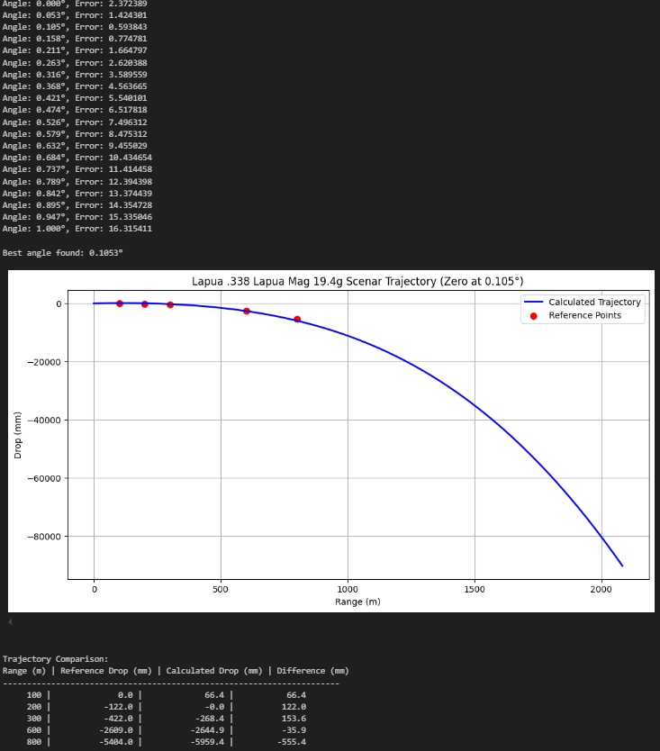

*Figure 3: Calculation of optimal firing angle.*

# Interpretation

### Conclusions and Future Exploration

Projectile motion in a 2d space is a complex system that can be modeled using the equations of motion and ballistic models. Using the limited real world data available from the manufacturer website, a semi-realistic trajectory can be generated. Future exploration could involve more detailed analysis of the sensitivity of the model to different parameters, such as wind speed, air density, and temperature. Additionally, the model could be extended to include more sophisticated drag models and other factors that affect the projectile's trajectory. The assessment of more informative real-world data would also be beneficial in improving the accuracy of the model.

Overall, this project provides a foundation for understanding the dynamics of a projectile in flight and the factors that influence its trajectory. The numerical methods used in this project can be applied to other systems and problems going forward.